# Chapter 2 Exercises

Note: You can open the .html file to see everything nicely formatted.

## Reading Response

Couclelis weighs in on the raster vs vector debate through both discussing the practical uses and the ways that we use raster and vector forms to display our conceptualizations of the world. For example, we practically use vector because of its history in spatial analysis to represent items that can be manipulated the way that we often the view the world as discrete objects to be manipulated. Raster represents how we view the world as continous space with various attributes and that clusters of space with the same attributes are loosely viewed as objects.  
However Couclelis’s paper is the most interesting when pushing the reader to go beyond traditional raster/vector understanding, showing that the world is not made up of as many objects as our mind concieves nor can it the significance of discrete objects be always reduced down to spread out attributes. Couclelis also argues that vector is best used for manipulation while raster is best used for description, but sometimes we may want to do neither. I appreciated Couclelis’s suggestion of creating fields that are not data layers and to use object oriented programming instead of euclidian lines, points, and polygons to represent objects, but I am unsure how ot implement these ideas without them becoming interchangable with vector and raster as opposed to alternatives.I prefer the suggestion of looking at space relationally, as that seems dismantle and thus expand the field-object dichotomy as opposed to simply reinforncing it with different methods.

```r
library(sf)
library(spData)
library(sp)
library(raster)
```

## Question 1

Use summary() on the geometry column of the world data object. What does the output tell us about: -Its geometry type? -The number of countries? -Its coordinate reference system (CRS)?

```r
summary(world["geom"])
```

```
##             geom
##  MULTIPOLYGON :177
##  epsg:4326    :  0
##  +proj=long...:  0
```

Geometry Type: MULTIPOLYGON Number of Countries: 177 (can be seen from num of polygons) CRS: WGS84 (EPSG 4326)

## Question 2

-What does the cex argument do (see ?plot)? -Why was cex set to the sqrt(world$pop) / 10000? -Bonus: experiment with different ways to visualize the global population.

This code was taken from the book but copied into this file for convenience.

```r
plot(world["continent"], reset = FALSE)
cex = sqrt(world$pop) / 10000
world_cents = st_centroid(world, of_largest = TRUE)
```

```
## Warning in st_centroid.sf(world, of_largest = TRUE): st_centroid assumes
## attributes are constant over geometries of x
```

```
## Warning in st_centroid.sfc(st_geometry(x), of_largest_polygon =
## of_largest_polygon): st_centroid does not give correct centroids for
## longitude/latitude data
```

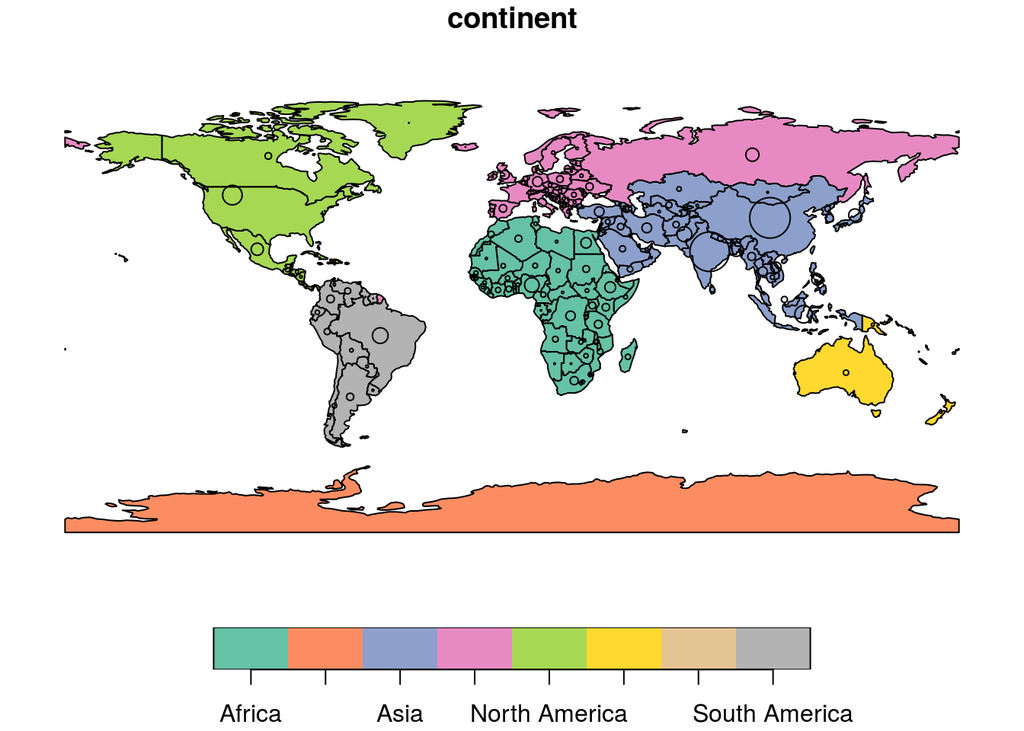

```r
plot(st_geometry(world_cents), add = TRUE, cex = cex)
```

## Question 3

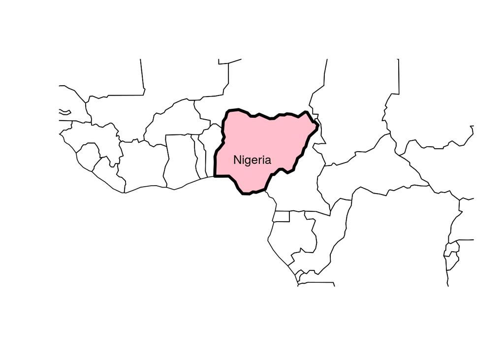

```r
# take the row associated with nigeria
nigeria = world[world$name_long == "Nigeria", ]
# plot the shape (geometry), set the bounding box, color, and line width
plot(st_geometry(nigeria), expandBB = c(1, 1, 0.5, 1), col = "pink", lwd = 4)
# get all the countries in afria
africa = world[world$continent == "Africa",]
# add all the other countries to the plot
plot(africa[0], add = TRUE)
# who determines what countries are part of of Africa and which borders are used?
# Why is this the default projection?
# challenge-- used text function by specifying loation and the text I wanted displayed
# determined x and y values through trial and error
text(x = 7, y = 8, labels = "Nigeria")
```

## Question 4

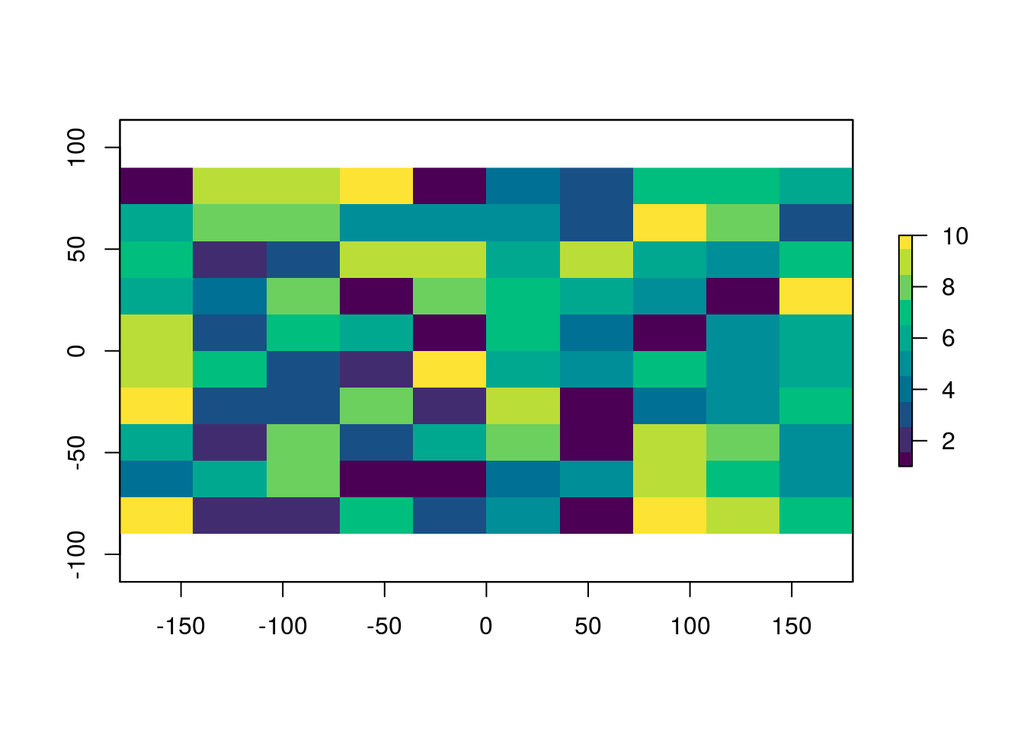

```r
# create a blank raster
my_raster = raster(nrows = 10, ncols = 10)
values = vector(mode = "numeric", length = 100)
 for (i in 1:100){
    values[i] = sample(1:10, 1);
 }


# I thought there was a better way to generate random numbers 100 times than a loop so I tried this but it didn't seem to work so I went back to the loop
# sapply(values, sample, 1:10, 1)

# take the values I generated and set raster label values at them
my_raster = setValues(my_raster, values)

# This line was from when I was trying to make sure my numbers were generating properly
#getValues(my_raster)

# plot raster by specifying my raster, which colors i want, transparency, and the max pixels in the raster
 plot(my_raster, col = hcl.colors(10, palette = "viridis", alpha = NULL), maxpixels = 100)
```

## Question 5

```r
# read in the file
# where did this layer come from? who made it? for what purpose?
file = raster(system.file("raster/nlcd2011.tif", package = "spDataLarge"))
#view info
file
```

```
## class      : RasterLayer
## dimensions : 1359, 1073, 1458207  (nrow, ncol, ncell)
## resolution : 31.5303, 31.52466  (x, y)
## extent     : 301903.3, 335735.4, 4111244, 4154086  (xmin, xmax, ymin, ymax)
## crs        : +proj=utm +zone=12 +ellps=GRS80 +towgs84=0,0,0,0,0,0,0 +units=m +no_defs
## source     : /home/rstudio-user/R/x86_64-pc-linux-gnu-library/3.6/spDataLarge/raster/nlcd2011.tif
## names      : nlcd2011
## values     : 11, 95  (min, max)
```

You can get the class, dimensions, resolution, extent, information such as projection, szone, units, the source, names, and the min max values